# Lab 7: Myopia

Categorical Exploratory Data Analysis

Present Group Member’s Names Go Here!

## Nightlight use and myopia

In a study reported in *Nature* (Quinn, 1999), a survey of 479 children found that those who had slept with a nightlight or in a fully lit room before the age of two had a higher incidence of nearsightedness (myopia) later in childhood.

In this study, there were two variables studied:

- `Light`: level of light in room at night (no light, nightlight, full light)
- `Sight`: level of myopia developed later in childhood (high myopia, myopia, no myopia).

**1. Which variable is the explanatory variable? Which is the response variable?**

Your answer goes here.

## Load the data

```r
myopia <- read_csv("data/ChildrenLightSight.csv")
```

**2. Click on the data set to open it up in the data previewer. What is the observational unit for this study?**

Your answer goes here.

## Visualizing One Categorical Variable

### Frequency Bar Plots

If we wanted to know how many children in our data set were in each level of myopia, we would create a frequency bar plot of the variable `Sight`. Creating a bar plot is similar to what we’ve done before.

**Step 1:** Set-up the data and the variable(s) of interest

**Step 2:** Define what geometric object should be plotted on the plot – now we’re using bars!

**Step 3:** Declare nice x- and y-axis labels

Let’s carry out these steps in the code chunk below!

```r
ggplot(data = myopia,
       mapping = aes(x = ____)
       ) +
  geom_bar() +
  labs(x = "____",
       y = "____")
```

[output not shown]

**3. Which sight group has the largest number of observations?**

Your answer goes here.

4. Using the bar plot, estimate how many children have *some* level of myopia.

Your answer goes here.

Using the skills you just acquired, make a bar plot visualizing how many children in our data set slept with a nightlight (`Light`).

**5. Which light group has the largest number of observations?**

### Relative Frequency Bar Plots

We could also choose to display the data as a proportion in a **relative frequency** bar plot. To find the relative frequency, we divide the count in each level by the total sample size. The resulting values are sample proportions.

To get *proportions* instead of *counts* we need to override the default statistic `geom_bar()` wants to use. To do this, we tell it we want proportions on the y-axis. We do this using the following code:

```
geom_bar(aes(y = ..prop.., group = 1))
```

Notice, there are two periods (**..**) before **and** after prop. These periods are necessary to define a new statistic that should be used for the y-axis.

6. Use this new code to modify the code you had previously. Copy-and-paste your code from the myopia bar plot above and change the y-axis to plot proportions instead of counts. Make sure to change your y-axis label to match proportions rather than counts!

```r
# Copy-and-paste your code from #4
# Add the aes() input to geom_bar() so your plot has proportions instead of counts!
```

7. Try removing the `group = 1` input from `geom_bar()`. What happens? What do your bars look like? Once you’ve answered the question, make sure to put the `group = 1` back in to your code!

## Summary statistics for categorical variables

The other part of Exploratory Data Analysis (EDA) is making summary statistics. For a categorical variable, this means making frequency tables and relative frequency tables. Let’s explore how to do that.

For this piece you are going to learn more about a tool you’ve seen previously – “the pipe.” This is a special operator written as `%>%`. The pipe is used as a connecting piece to keep your data flowing through a pipeline. We will use the pipe to string together two R functions:

- `count()`, which counts the number of observations (rows) for each group of a categorical variable
- `mutate()`, which modifies our dataset by adding new variables or changing existing variables

Let’s start with a short data pipeline.

```r
myopia %>%
  count()
```

| n |
| --- |
| 479 |

**8. What does the variable n tell us?**

We can add another piece to the pipeline to make it a bit more interesting. Let’s add the `Sight` variable into the `count()` function and see what we get!

```r
myopia %>%
  count(Sight)
```

| Sight | n |
| --- | --- |
| High Myopia | 16 |
| Myopia | 122 |
| No Myopia | 341 |

**9. How many observations are in the Myopia and High Myopia groups?**

Finally, we might want to add one more piece to the pipeline to create a `proportion` variable of the relative frequencies of each level of `Sight`. *Hint:* Think about what your numerator for your proportion should be based on your resulting code chunk output above.

```r
myopia %>%
  count(Sight) %>%
  mutate(proportion = n / sum(n))
```

| Sight | n | proportion |
| --- | --- | --- |
| High Myopia | 16 | 0.03340292 |
| Myopia | 122 | 0.25469729 |
| No Myopia | 341 | 0.71189979 |

**10. What proportion of children have high myopia?**

Now, take the code you just filled in and address the following question about the `Light` variable!

**11. What proportion of children slept with full light?**

```r
# Put your code here to find the proportion of children that slept with different nightlights
```

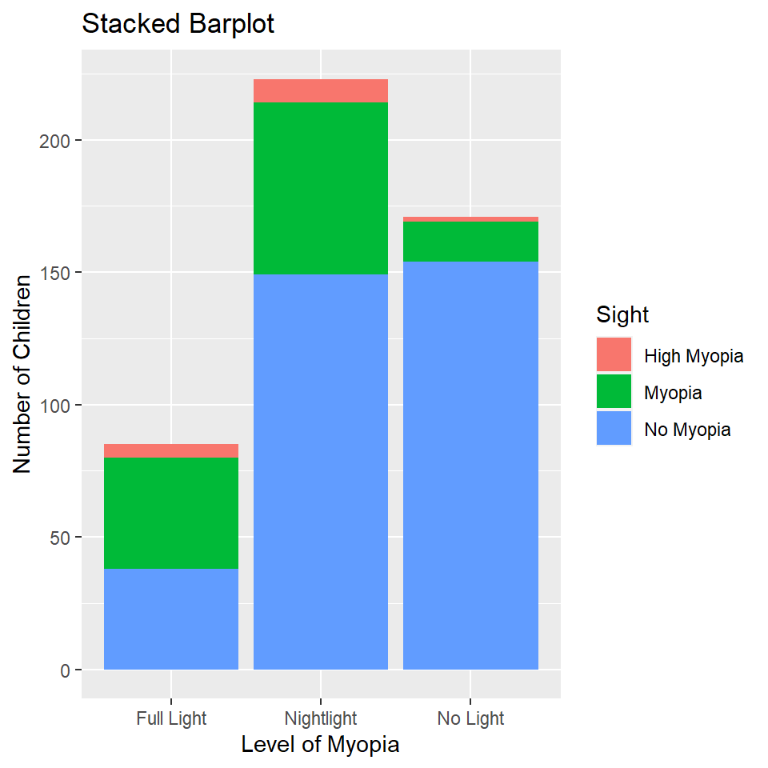

```r
# Code to create the stacked barplot
ggplot(data = myopia,
       mapping = aes(x = Light, fill = Sight)
       ) +
  geom_bar(position = "stack") +
  labs(x = "Level of Myopia",
       y = "Number of Children",
       title = "Stacked Barplot")
```

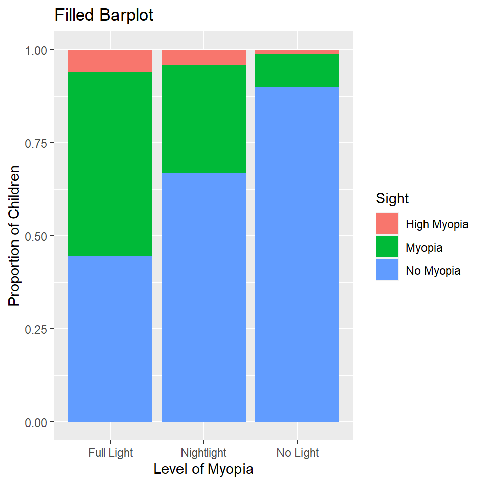

```r
# Code to create the filled barplot
ggplot(data = myopia,
       mapping = aes(x = Light, fill = Sight)
       ) +
  geom_bar(position = "fill") +
  labs(x = "Level of Myopia",
       y = "Proportion of Children",
       title = "Filled Barplot")
```

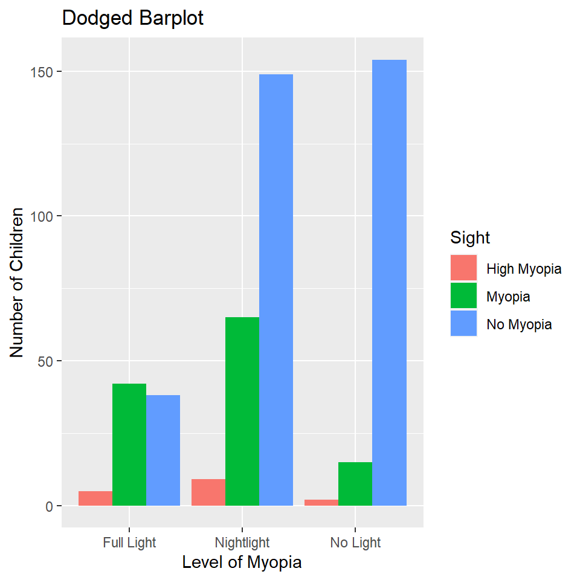

```r
# Code to create the dodged barplot
ggplot(data = myopia,
       mapping = aes(x = Light, fill = Sight)
       ) +
  geom_bar(position = "dodge") +
  labs(x = "Level of Myopia",
       y = "Number of Children",
       title = "Dodged Barplot")
```

12. The code above creates the stacked, filled, and dodged barplots. What part of the code changes the way the bars are displayed between the three types of plots?

Your answer goes here.

13. Fill in the code below to generate `count()`s of the `Light` and `Sight` variables. Once you’ve filled in the code, click the play button to get a contingency table of the counts!

```r
myopia %>%
  count(____, ____) %>%
  pivot_wider(names_from = Sight, values_from = n) %>%
  adorn_totals(where = c("row", "col"))
```

[output not shown]

**14. How many children slept with a nightlight?**

Your answer goes here.

**15. How many children who slept with a nightlight have Myopia?**

Your answer goes here.

If we want to display our contingency tables in proportions, we can change the code above to use the `adorn_percentages()` function instead of the `adorn_totals()` function. It’s as simple as that! We do, however, need to tell `adorn_percentages()` how the percentages should be calculated. To calculate the percentage, we need to specify if the denominator (for the percentage) should come from the `"row"` total or from the `"col"` total.

```r
myopia %>%
  count(Light, Sight) %>%
  pivot_wider(names_from = Sight, values_from = n) %>%
  adorn_percentages(denominator = "____")
```

[output not shown]

Your answer goes here.

18. Using the filled bar plot and the proportion contingency table above, do you think the proportion of people with Myopia differs between the different levels of light? Explain your answer in detail.

Your answer goes here.